# Demo of Using the Combined Data

Jarrett Byrnes

3/4/2021

## The Combined Data

The combined intertidal/subtidal data is in a long format with all abundance data sets combined. Let’s take a look.

```r
library(dplyr)
library(tidyr)
library(ggplot2)

dat <- readRDS("tidy_data/combined_all_abundance_data.RDS")

head(dat)
```

```
## # A tibble: 6 x 28
##    YEAR SITE     TRANSECT  INTERTIDAL_TRANSE… LEVEL PROTOCOL   ORGANISM    SIZE
##   <dbl> <chr>    <chr>                  <dbl> <dbl> <chr>      <chr>       <chr>
## 1  2014 NE Appl… Broad Co…                 18    NA QUAD       Agarum cla… <NA>
## 2  2014 NE Appl… Broad Co…                 18    NA PERCENT_C… Anomia      <NA>
## 3  2014 NE Appl… Broad Co…                 18    NA PERCENT_C… Aplidium p… <NA>
## 4  2014 NE Appl… Broad Co…                 18    NA QUAD       Asterias f… <NA>
## 5  2014 NE Appl… Broad Co…                 18    NA QUAD       Asterias r… <NA>
## 6  2014 NE Appl… Broad Co…                 18    NA SWATH      Asterias r… <NA>
## # … with 20 more variables: ORGANISM_TYPE <chr>, MEASURE <chr>, VALUE <dbl>,
## #   AREA <dbl>, SP_CODE <chr>, GROUP <chr>, DIVISION.FAMILY <chr>,
## #   COMMON.DIVISION.NAME <chr>, COMMON.NAME <chr>, KINGDOM <chr>, PHYLUM <chr>,
## #   CLASS <chr>, ORDER <chr>, FAMILY <chr>, GENUS <chr>, TYPE <chr>,
## #   SUBTYPE <chr>, APHIAID <chr>, VALID_NAME <chr>, VALID_AUTHORITY <chr>
```

Year through intertidal transect columns give us identifying information. Level gives us information about tide height, and if it is NA then we are in the subtidal. We then have protocol, indicating how organisms were assessed, organism, the name used in each dataset to identify the organism commonly, size for those that were split into adults and juveniles (subtidal data) or other size classes (e.g., fish), organism type for intertidal surveys when looking at primary or secondary substrate, measure to give us units for the following value averaged across sample replicates, and after value the area of a single replicate in square meters. After this is group and taxonomic information which varies slightly between intertidal and subtidal datasets.

The advantage to the long format is that it will be easier to aggregate groups later on in analysis. Also, it’s easy to `tidyr::pivot_wider()` to make a wide data frame for analysis, while maintaining a lot of data in a compact form.

## Example with Corralina officinalis

```r
co <- dat %>%
  filter(ORGANISM == "Corallina officinalis") %>%
  filter(is.na(SIZE)) %>% #no juvies
  group_by(across(YEAR:INTERTIDAL_TRANSECT), MEASURE) %>%
  summarize(VALUE = mean(VALUE)) %>%
  ungroup()
```

Great! Now let’s pivot wider, assuming that any missing measurements are 0.

```r
co_wide <- co %>%
  pivot_wider(names_from = MEASURE,
              values_from = VALUE,
              values_fill = 0) %>%
  rename(INTERTIDAL_COVER = Percent_Cover)
```

Cool! What’s this look like?

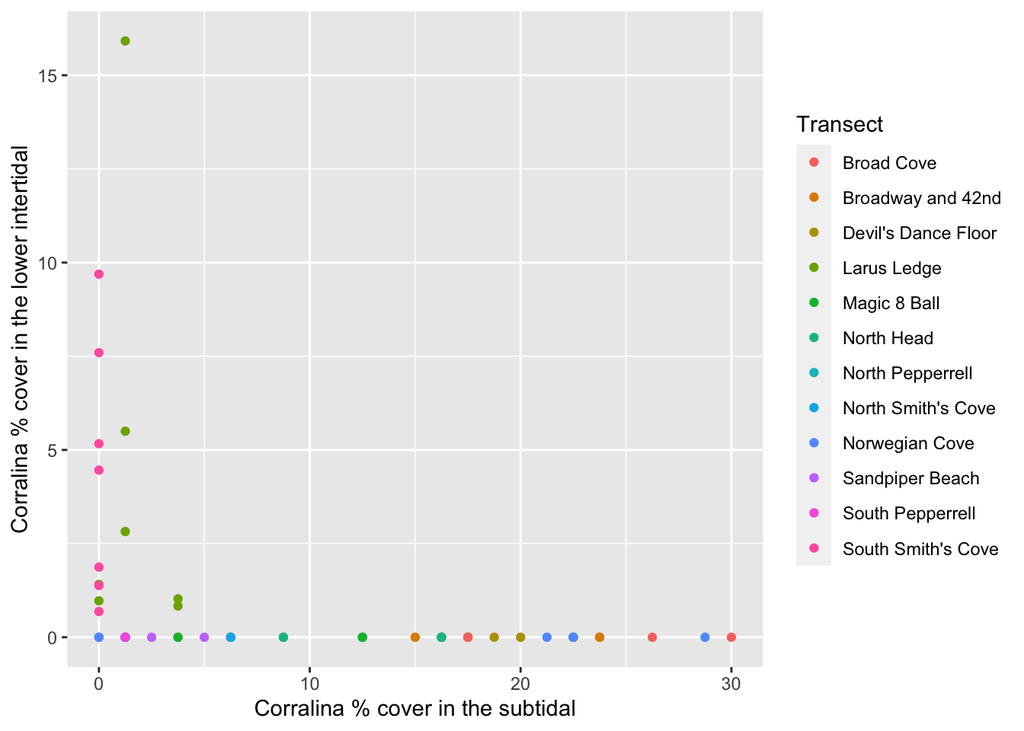

```r
ggplot(data = co_wide,
       aes(x = PERCENT_COVER, y = INTERTIDAL_COVER, color = TRANSECT)) +
  geom_point() +
  labs(x = "Corralina % cover in the subtidal",
       y = "Corralina % cover in the lower intertidal",
       color = "Transect")
```

## Comparing multiple species

```r
troph <- dat %>%
  filter(ORGANISM %in% c("Cancer borealis", "Littorina littorea")) %>%
  filter(PROTOCOL %in% c("SWATH", "Intertidal_Count")) %>%
  group_by(across(YEAR:INTERTIDAL_TRANSECT),
           PROTOCOL, ORGANISM) %>%
  summarize(VALUE = mean(VALUE)) %>%
  ungroup() %>%
  pivot_wider(names_from = c(PROTOCOL, ORGANISM),
              values_from = VALUE,
              values_fill = 0) %>%
  janitor::clean_names() #what? they were dirty
```

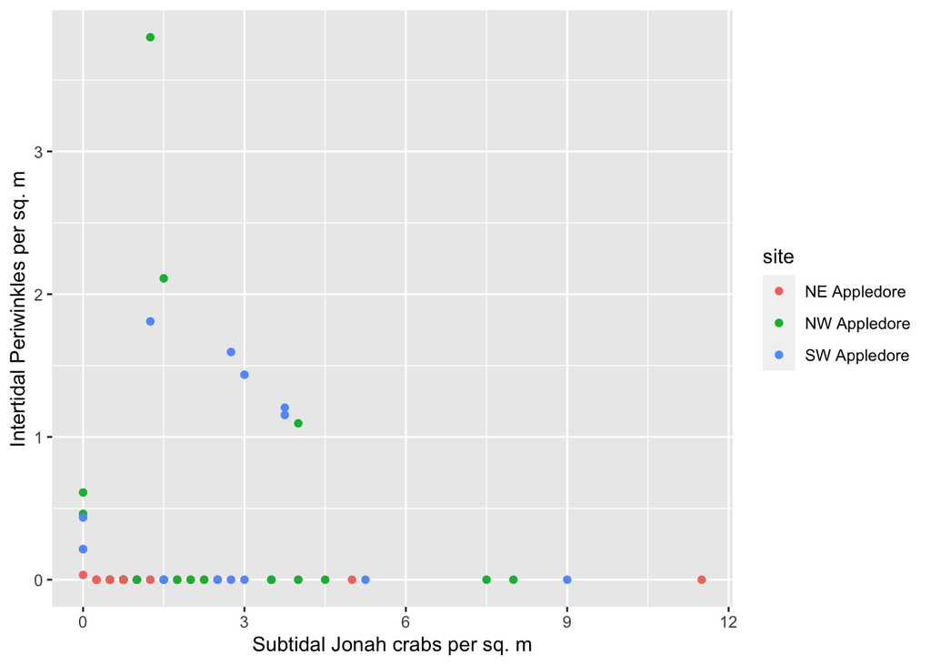

```r
ggplot(troph,
       aes(x = swath_cancer_borealis,
           y = intertidal_count_littorina_littorea,
           color = site) ) +
  geom_point() +
  labs(x = "Subtidal Jonah crabs per sq. m",
       y = "Intertidal Periwinkles per sq. m")
```

Huh!